# Week 9 / Exploratory Data Analysis, ggplot2, Lab 07

AG Schissler

Monday October 28, 2019

## I. Opening

### I. Start-of-class work

1. Log in the your workstation.
2. Open the RStudio application on your machine.
3. Open 18_ggplot2_startLab07.Rmd from website so that you can work along the lecture.
4. Open lab_07_ggplot2_graphics.Rmd to have the lab available.

### This week’s agenda

- Continue *Working with data* Unit II.
- Focus on using R to plot data to conduct exploratory data analysis (EDA).
- Now `ggplot2` will be used.

### Today learning outcomes

Students will be able to

- use `ggplot2` to plot data

## II. Introduction to `ggplot2` in R

`ggplot2` is an R package created by Hadley Wickham (now head data scientist at RStudio) plots and uses syntax inspired by Leland Wilkinson’s *The Grammar of Graphics* (1st edition in 1999). I make my publication-quality plots using `ggplot2`. Now `ggplot2` has a huge community of developers and users. Some links:

- https://ggplot2.tidyverse.org/
- https://ggplot2.tidyverse.org/reference/

### Some fun viz packages that play well with `ggplot`:

- `ggally`
- `cowplot`
- `ggforce`

## III. Using `ggplot2` to create plots

I’ll keep this brief since you already have had a datacamp module on `ggplot2`. Some remarks from my experience:

### Quick plotting for to explore and clean datat

`qplot()` is nice as it uses syntax inspires by base `graphics` commands. But it also layers well as it is a ggplot object.

### Format your data into *long* format

As non-running example:

```r
## empirical is efancy for empirical data
## method_names <- c("empirical", "independent", "approxR", "condreg", "Spearman", "Kendall")
method_names <- c("Empirical", "Independent", "ApproxR", "Spearman", "Kendall")
num_methods <- length(method_names)
all_dat <- data.frame(dat_source = rep( method_names, each = d),
                      index = rep(1:d, times = num_methods))

## aggregate z scores (order matters!)
all_dat$z_score <- c( sort(empirical_z_values, decreasing = T),
                     sort(sim_ind_z_values, decreasing = T),
                     sort(sim_approxR_z_values, decreasing = T),
                     ## sort(sim_condreg_z_values, decreasing = T),
                     sort(sim_spearman_z_values, decreasing = T),
                     sort(sim_kendall_z_values, decreasing = T) )

## aggregate p values (order matters
all_dat$p_value <- c( sort(empirical_p_values),
                     sort(sim_ind_p_values),
                     sort(sim_approxR_p_values),
                     ## sort(sim_condreg_p_values),
                     sort(sim_spearman_p_values),
                     sort(sim_kendall_p_values) )
```

See how the `p_value` variable contains all the values for each method? It is long in the sense that you do not have separate columns for each method’s p-value (that would be *wide* format). In long format, there is a variable that contains a factor for the method type. Then you can easily map that categorization (label) to aesthetic variables, as seen in the next example.

### Build plots in layers and inspect at each point

```r
## p values, subset to first N indeces?
p0 <- ggplot(all_dat, aes(x=index, y= p_value, color=dat_source ))
p1 <- p0 + geom_point(size = 3)
p2 <- p1 + labs(x = "Sorted Index", y = "P-values", color = "Data source") + theme_bw()
## pP <- p2 + geom_abline(slope = 1, intercept = 0)
pP <- p2
## + scale_color_discrete(labels = c("Kendall Copula", "Empirical", "Independent"))
pP ## prints the plot
```

### Try the available themes

- `theme_bw()` is great for articles and other docs that people may print on black-and-white printers.

### For complicated plots and inspiration

When I construct a plot, I often look for code snippets to hack at rather than creating from scratch. A nice gallery of examples

https://www.r-graph-gallery.com/

### Violin plots to visualize distributions

```r
# Library
library(ggplot2)

# create a dataset
data <- data.frame(
  name=c( rep("A",500), rep("B",500), rep("B",500), rep("C",20), rep('D', 100)  ),
  value=c( rnorm(500, 10, 5), rnorm(500, 13, 1), rnorm(500, 18, 1), rnorm(20, 25, 4), rnorm(100, 12, 1) )
)
head(data)
```

```
##   name     value
## 1    A 15.504846
## 2    A 10.718857
## 3    A  9.411232
## 4    A  5.439658
## 5    A  2.812069
## 6    A  6.014552
```

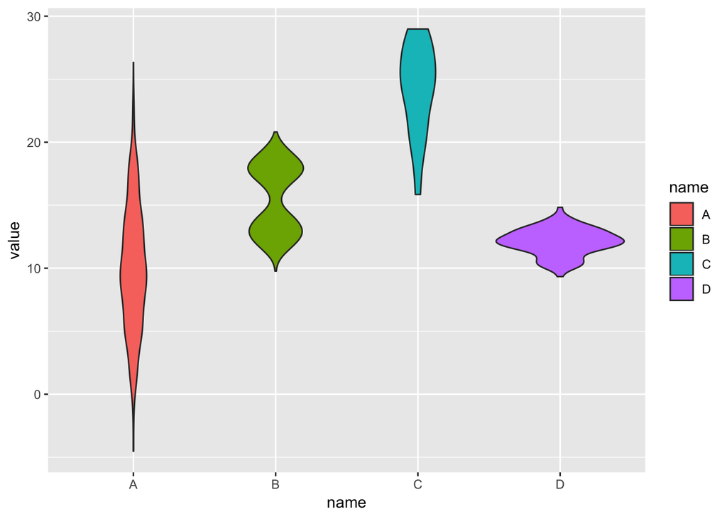

```r
# Most basic violin chart
p <- ggplot(data, aes(x=name, y=value, fill=name)) + # fill=name allow to automatically dedicate a color for each group
  geom_violin()

p
```

## IV. Begin Lab 07

### Some suggested steps

1. This lab is different in the plots are the same as in Lab 06.
2. But you are to use `ggplot2` now and instead of base graphics.
3. So it is helpful to have your Lab 06 handy to compare to.

## V. Summary

- Explain to a friend the differences between base and `ggplot2` plot construction.